# The analysis of white wine by lin shou bao

# Multivariate Analysis

### Talk about some of the relationships you observed in this part of the investigation. Were there features that strengthened each other in terms of looking at your feature(s) of interest?

1.利用多变量分析，更加直观的刚看到密度和酒精、残糖量之间的关系。

2.没有发现相互之间可以加强的特征变量。

### Were there any interesting or surprising interactions between features?

1.density与residual.sugar保持正相关，与alcohol保持负相关。从侧面说明了density和quality表面存在相关关系，其实两变量之间不存在相关性。

2.当酒精含量低于10时，so2总量和质量是负相关关系；当酒精含量大于11时，so2总量和质量是正相关关系。

3.酒精含量在11以上时，总酸度和质量的负相关性比较明显。

4.在酒精含量低于11时，氯化物与质量的负相关较明显。

### OPTIONAL: Did you create any models with your dataset? Discuss the strengths and limitations of your model.

# Final Plots and Summary

### Plot One

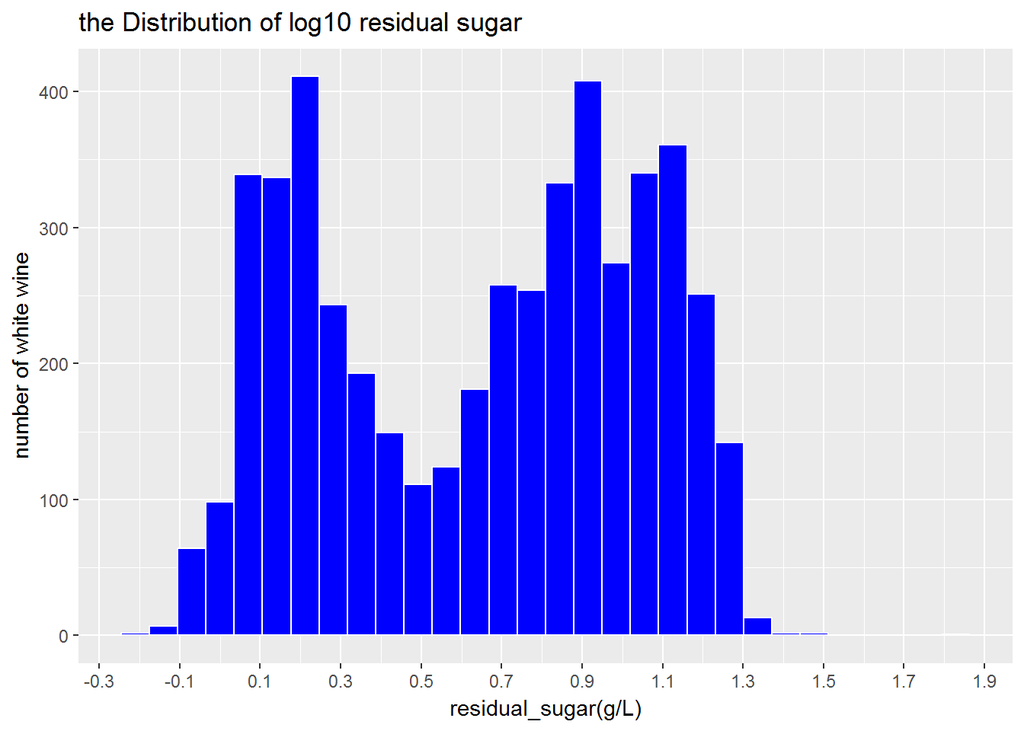

### Plot Two

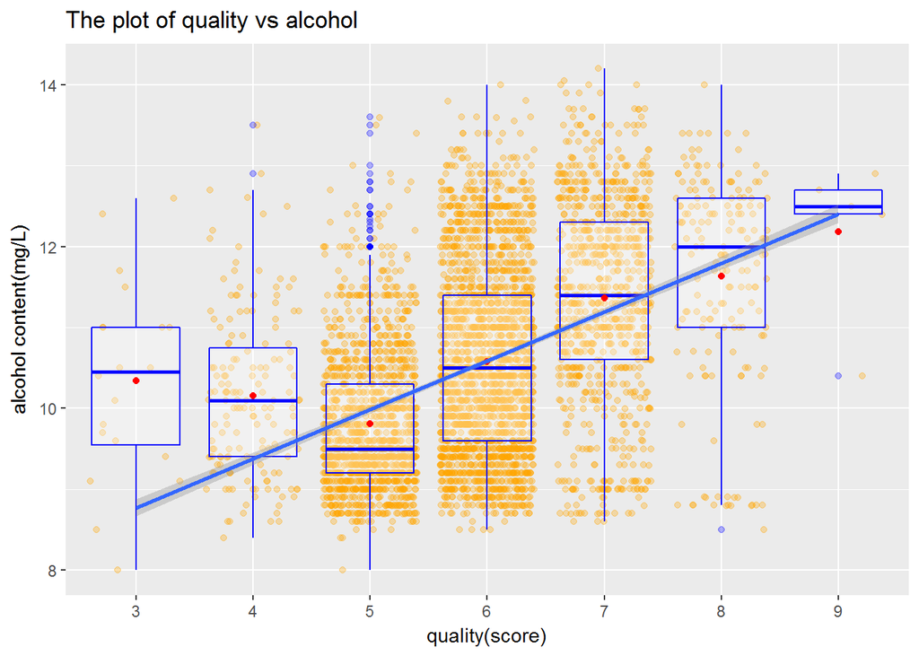

### Description Two

利用箱型图，平均值以及线性回归直线，协助分析较难发现规律的散点图，可以发现酒精变量(alcohol)与质量变量(quality)是正相关关系。

### Plot Three

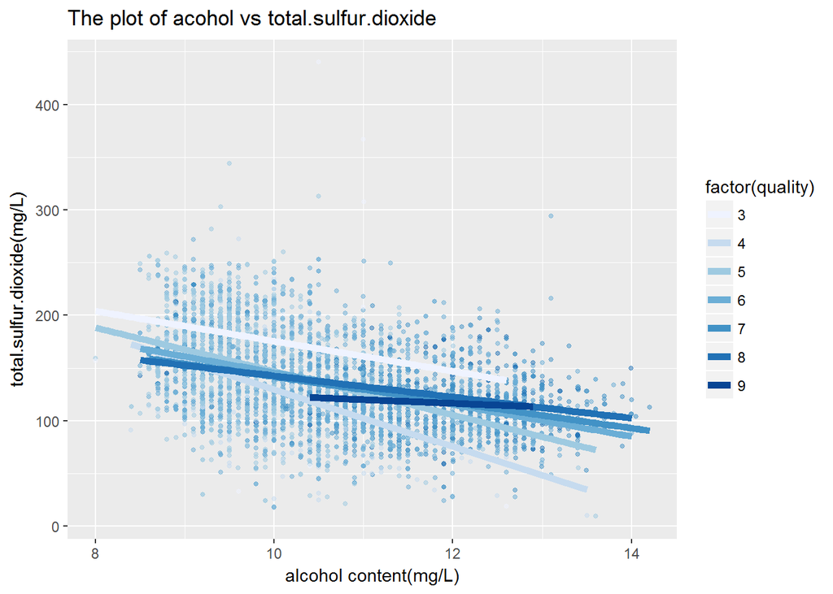

### Description Three

当酒精含量低于10的时候，so2总量和质量是负相关关系；当酒精含量大于11的时候，so2总量和质量是正相关关系。

# Reflection

首先，了解了整个数据集中的数据结构、数据量以及各个变量的总结数据，观察每个变量生成的直方图，发现多个变量存在异常值，为了避免影响分析， 在接下来的分析中进行了剔除。

其次，计算数据集中两两变量之间的相关系数，可以加快数据之间规律的速度，观察了和quality存在相关关系的变量的散点图，同时也观察了其他变量之间的 散点图，发现有些变量之间存在联系。有个奇怪的事情是pH值反映的就是液体的酸碱度，应该会出现很大的相关性，但是我们发现pH和fixed.acidity相关性并不特别显著, 原因可能是观测值只有4898个，偏少；另一个原因是异常值对结果的影响。

最后，对多个变量进行分析，发现两个现象：一是density,表面上和quality存在相关性，其实没有相关性；二是当酒精含量在某个范围时，与quality负相关关系的 变量表现出很有意思的现象。

最终，与quality相关的变量建立了拟合线性回归模型，但是结果很惊讶，只能解释20%的量的方差，可能原因是质量评分结果是根据人的感觉进行评分，存在主观因素， 导致对最终的结果会有偏差。

对未来的提议：R语言作为一门EPA工具，操作简单，容易上手，但是对一些复杂或者规律不限的数据，就很需要扎实的知识功底以及经验。因此未来要做好数据分析工作， 就需要我们不断提升对数据的敏感性以及扎实的技能。